# Randomized Controlled Trials (II)

Adam La Caze

Semester 1, 2023

## Objectives

- Be able to interpret the key statistical results of a randomized trial
- Be able to find, calculate and interpret different measures of treatment effect
- Be able to consider aspects that influence the external validity of a randomized trial

## Key concepts

- Randomized trials are set up to reliably test the **primary endpoint**; secondary endpoints and subgroup analyses are often less reliable
- Non-inferiority trials provide an alternative to superiority trials. Non-inferiority trials test whether a new treatment is **no worse** than standard treatment
- $p$ values and confidence intervals are a measure of the compatibility of observed results against a statistical model
- Relative and absolute measures of effect provide different information and can be misinterpreted
- Assessing external validity requires consideration of the trial methods, participants and outcomes as well as the patients and the contexts of care for those who receive the treatment in routine care

# Interpreting the primary statistical results

## CURE Study

Statistical results for the primary endpoint

> The first primary outcome …occurred in 9.3 percent of the patients in the clopidogrel group and 11.4 percent of the patients in the placebo group (relative risk with clopidogrel as compared with placebo, 0.80; 95 percent confidence interval, 0.72 to 0.90; $P < 0.001$).

How should we interpret these results?

## CURE Study: Take homes!

1. The null hypothesis is that the *true* relative risk is 1 (i.e. no difference in primary endpoint event rates in participants that received clopidogrel and aspirin compared to aspirin alone)
2. The $p$ value for the primary endpoint is low ($p < 0.001$); the observed data (relative risk 0.80) would be unexpected **if the null hypothesis and associated statistical model was true**
4. **Inference**: clopidogrel in addition to aspirin reduces the risk of event(s) within the primary endpoint (in the participants in the trial, treated under the conditions of the trial)
5. The 95% confidence interval is a measure of the precision of the trial; the size of CURE means that the 95% confidence interval is quite small: 0.72–0.90

# Types of trial

“Better than” or “no worse than”

## Superiority trials

Superiority trials seek to test whether the treatment under investigation is **superior** to control

The **null hypothesis** is that there is no differences between groups

The **alternative hypothesis** is that the investigational treatment is **better than** control

## Non-inferiority trials

Non-inferiority trials seek to test whether the treatment under investigation is **no worse than** control

The **null hypothesis** is that the treatment under investigation is **worse** than control

The **alternative hypothesis** is that the investigational treatment is **no worse than** control

## How non-inferiority trials work?

Treatment *B* is **non-inferior** to Treatment *A*, when the upper range of the confidence interval for Treatment *B* is lower than the pre-set **non-inferiority margin** when compared to Treatment *A*.

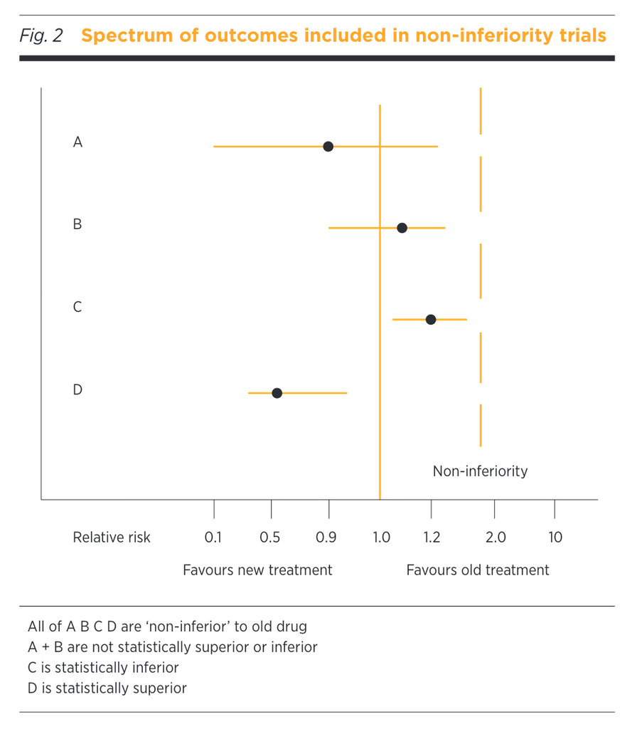

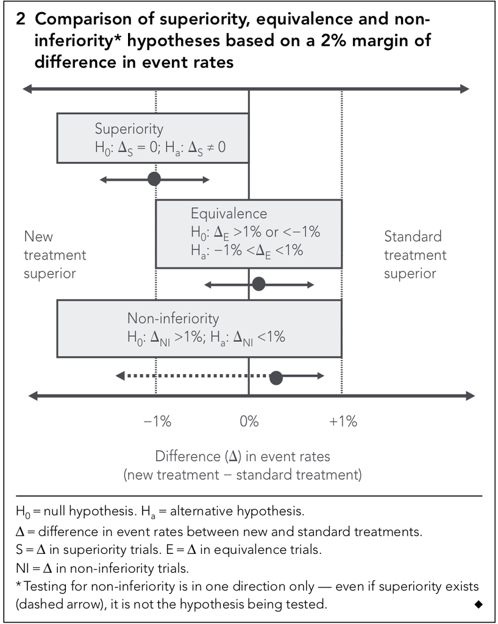

## Things to consider for non-inferiority trials

Does the non-inferiority margin make clinical sense?

If the margin is “too high”, it might mean that the new drug is worse than control (in reality) even if it is non-inferior (according to the statistical analysis)

Ewald (2013) uses the example of the RE-LY trial, which compared dabigatran to warfarin for stroke prevention in atrial fibrillation.

The observed result of dabigatran 110 mg v warfarin was a RR of 0.91 (95% CI, 0.74–1.11).

We need to think about some sources of bias differently:

- Intention-to-treat analysis are conservative and risk treatments appearing non-inferior when they are not
- Need to be careful that the comparator **is** superior to placebo (otherwise the investigational treatment might be no better than placebo)

# Critical Appraisal: Results

## How large was the treatment effect? (4)

## CURE Results, benefits

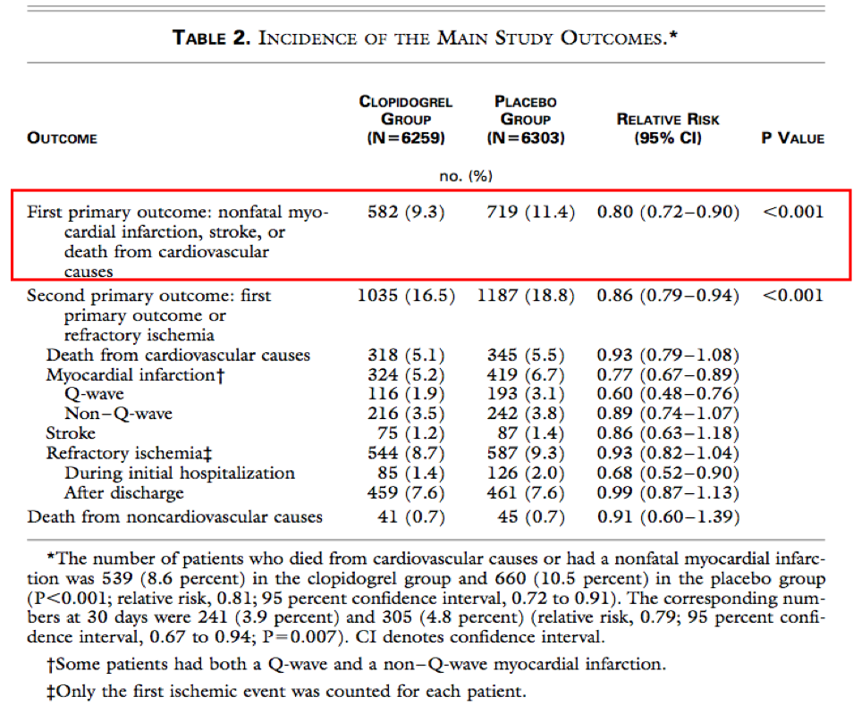

## Types of measures of effect

**Relative measures**

provide a ratio measure of the effect relative to control. Doesn’t take into account baseline risk; tends to be more stable across different populations.

**Absolute measures**

provides a difference measure of the effect relative to control. Takes into account baseline risk; differs considerably across different populations.

## Women’s Health Initiative Study (2002)

- WHI assessed the risks and benefits of long-term hormone replacement therapy in older women.
- A key finding was that HRT *increased* rates of coronary heart disease in this group.
- **Relative risk**: there was a 29% relative increase in coronary heart disease in the HRT group
- **Absolute risk**: an additional 7 patients per 10,000 person-years suffered coronary heart disease in the HRT group
- **Number needed to harm**: if you treat 1429 women with HRT rather than placebo for 1 year for one additional woman will suffer coronary heart disease

The above measures provided in relative and absolute terms are different ways to represent the *same* effect.

## Calculating measures of effect

2 x 2 table for a RCT

|  | Endpoint | No endpoint | Total |
| --- | --- | --- | --- |
| Treatment | a | b | (a + b) |
| Control | c | d | (c + d) |

**Risk** is another word for probability; in this context we also have **incidence** and **event rate**.

The *risk* of the endpoint in the treatment group, $I_t$, is

$$I_t = \frac{a}{(a+b)}$$

The *risk* of the endpoint in the control (or placebo) group, $I_c$, is

$$I_c = \frac{c}{(c+d)}$$

**Relative risk** is simply the ratio of these two risks:

$$RR = \frac{I_t}{I_c}$$

**Relative risk reduction (or increase)** is the increase or decrease in relative risk compared to 1. For example if $I_c > I_t$, the relative risk reduction ($RRR$) is:

$$RRR = 1 - RR$$

The **absolute risk difference** is the difference between the two risks. The absolute risk difference is typically presented as positive and described as either an **absolute risk reduction** or **absolute risk increase** as appropriate.

$$ARR = I_c - I_t$$

$$ARI = I_t - I_c$$

The **number needed to treat ($NNT$) and/or harm ($NNH$)** provide a way to express the absolute effect of the treatment. In the formula below $ARR$ ($ARI$) is expressed as a percent.

$$NNT = 100/ARR$$

$$NNT = 100/ARI$$

## Hazard ratio

- Hazard ratios are commonly reported and are a ratio of the hazard rate in the treatment group divided by the hazard rate in the control group
- Hazard ratios are similar to relative risk, but have the benefit that they take into consideration the amount of time a participant is **exposed** to the drug

The hazard rate uses the data observed in the trial to estimate the probability of a participant who is yet to experience the event, experiencing the event in the next time interval.

## CURE, measures of effect

|  | Endpoint | No endpoint | Total |
| --- | --- | --- | --- |
| Clopidogrel plus aspirin | 582 | 5677 | 6259 |
| Aspirin alone | 719 | 5584 | 6303 |

## Measures of effect: CURE, benefits

- $I_c$: 11.4% event rate in the patients randomised control (aspirin alone)
- $I_t$: 9.3% event rate in the patients randomised intervention (aspirin plus clopidogrel).
- Absolute risk reduction: $I_c - I_t = 2.1\%$
- Relative risk: $I_t/I_c = 0.82$ or 82%
- Relative risk reduction: $1 - RR = 0.18$ or 18%
- Number needed to treat (NNT): $100/ARR = 48$

It is important to put the NNT into context:

> You need to treat 48 high risk patients with acute coronary syndrome with a combination of aspirin and clopidogrel for 9 months rather than aspirin alone to reduce one additional event within the primary endpoint.

This puts the *benefits* of clopidogrel plus aspirin into perspective. It is also important to consider any key harms.

## CURE Results, safety

> Major bleeding was significantly more common in the clopidogrel group (3.7 percent in the clopidogrel group as compared with 2.7 percent in the placebo group; relative risk, 1.38; 95 percent confidence interval, 1.13 to 1.67; P = 0.001)

## Measures of effect: CURE, safety

- $I_c$: 2.7% event rate in the patients randomised control (aspirin alone)
- $I_t$ 3.7% event rate in the patients randomised intervention (clopidogrel plus aspirin)
- Absolute risk increase: $I_t - I_c = 1\%$
- Relative risk: $I_t/I_c = 3.7/2.7 = 1.4$ or 140%
- Relative risk increase: $RR - 1 = 0.4$ or 40%
- Number needed to harm (NNH): $100/ARI = 100$

## CURE: Bottom line

> If you treat 100 high-risk ACS patients with a combination of aspirin and clopidogrel for 9 months rather than aspirin alone: there will be 2 fewer events from the primary endpoint (cardiovascular death, nonfatal MI or stroke) and 1 additional major bleed.

## How precise was the estimate of the treatment effect? (5)

Application to CURE Study

| Primary endpoint (benefit) | $RR = 0.80$; 95% CI 0.72–0.90 |
| --- | --- |
| Major bleed (harm) | $RR = 1.38$; 95% CI 1.13–1.67 |

# Critical Appraisal: External validity

## Will the results help me caring for my patient? (6)

External validity refers to the degree to which the results of the study are accurate for patients receiving the treatment in routine care

External validity is a judgment

## External validity

Assessing external validity requires consideration of:

- The trial, its participants, and the methods employed within the trial
- The ways in which **patients** receiving treatment in routine care are similar or different to the participants of the trial
- The ways in which the **care of patients** in routine care differs from the care received in the trial (e.g. additional monitoring)

How should we interpret CURE in terms of external validity?

## Some considerations

- The NNH/NNT ratio is quite small (treat 100: prevent two significant clinical events, cause one significant clinical event)
- CURE recruited a highly selected population: high risk for cardiac events, excluding patients at high-risk of bleeding
  - CURE is likely to underestimate harms related to bleeding
- It is also possible intention-to-treat analyses may lead to an under estimation of benefit (though not much specific evidence of this)

## Evidence since CURE

- **Retrospective cohort study** demonstrates high risk of late major bleeding in patients on **triple antithrombotic therapy** in patients with AF and an indication for dual antiplatelet therapy.
- Absolute risk increase of late major bleeding 17.8%, $p=0.006$ (Manzano-Fernández et al. 2008)
- Clopidogrel is a pro-drug: CYP2C19 function varies in the population and this has been linked to clinical outcomes (Wallentin et al. 2010)
- Some proton pump inhibitors (omeprazole, esomeprazole) appear to reduce the conversion of clopidogrel to its active metabolite (Gilard et al. 2008; Angiolillo et al. 2011)

## CURE Summary

- Aspirin plus clopidogrel appears to benefit high-risk patients with acute coronary syndrome in terms of reducing mortality or a cardiac event
- This comes at a considerable risk of bleeding
- Patients at high risk of bleeding might experience more harm than benefit from clopidogrel plus aspirin
- It is not considered necessary to test CYP2C19 function, but if we know it and the patient is a poor metaboliser of clopidogrel: avoid
- Avoid clopidogrel and (es)omeprazole (different resources give different advice on this)

## References

Angiolillo, D J, C M Gibson, S Cheng, C Ollier, O Nicolas, L Bergougnan, L Perrin, F P LaCreta, F Hurbin, and M Dubar. 2011. “Differential Effects of Omeprazole and Pantoprazole on the Pharmacodynamics and Pharmacokinetics of Clopidogrel in Healthy Subjects: Randomized, Placebo-Controlled, Crossover Comparison Studies.” *Clinical Pharmacology and Therapeutics* 89 (1): 65–74. https://doi.org/10.1038/clpt.2010.219.

Ewald, Ben. 2013. “Making Sense of Equivalence and Non-Inferiority Trials.” *Australian Prescriver* 36: 170–73. https://www.nps.org.au/australian-prescriber/articles/making-sense-of-equivalence-and-non-inferiority-trials.

Gilard, M, B Arnaud, J Cornily, G Legal, K Lacut, G Lecalvez, J Mansourati, D Mottier, J Abgrall, and J Boschat. 2008. “Influence of Omeprazole on the Antiplatelet Action of Clopidogrel Associated With AspirinThe Randomized, Double-Blind OCLA (Omeprazole CLopidogrel Aspirin) Study.” *Journal of the American College of Cardiology* 51 (3): 256–60. https://doi.org/10.1016/j.jacc.2007.06.064.

Manzano-Fernández, Sergio, Francisco J Pastor, Francisco Marín, Francisco Cambronero, Cesar Caro, Domingo A Pascual-Figal, Iris P Garrido, Eduardo Pinar, Mariano Valdés, and Gregory Y H Lip. 2008. “Increased Major Bleeding Complications Related to Triple Antithrombotic Therapy Usage in Patients with Atrial Fibrillation Undergoing Percutaneous Coronary Artery Stenting.” *Chest* 134 (3): 559–67. https://doi.org/10.1378/chest.08-0350.

Wallentin, Lars, Stefan James, Robert F. Storey, Martin Armstrong, Bryan J. Barratt, Jay Horrow, Steen Husted, et al. 2010. “Effect of Cyp2c19 and Abcb1 Single Nucleotide Polymorphisms on Outcomes of Treatment with Ticagrelor Versus Clopidogrel for Acute Coronary Syndromes: A Genetic Substudy of the PLATO Trial.” *The Lancet* 376 (9749): 1320–28. https://doi.org/10.1016/S0140-6736(10)61274-3.

Women’s Health Initiative Investigators. 2002. “Risks and Benefits of Estrogen Plus Progestin in Health Postmenopausal Women.” *Journal of American Medical Association* 288 (3): 321--33. https://doi.org/10.1001/jama.288.3.321.